# **Tuned Model Results**

> **Notebook Author:** Brian Keith (bkeith9@gatech.edu)  
> **Purpose:** The purpose of this final notebook is to take in the results for the tuned models and evaluate the performance to determine the best set of models which will be discussed in the final report.

> **Data Citation:**
> - Andreas Miltiadous and Katerina D. Tzimourta and Theodora Afrantou and Panagiotis Ioannidis and Nikolaos Grigoriadis and Dimitrios G. Tsalikakis and Pantelis Angelidis and Markos G. Tsipouras and Evripidis Glavas and Nikolaos Giannakeas and Alexandros T. Tzallas (2023). A dataset of EEG recordings from: Alzheimer's disease, Frontotemporal dementia and Healthy subjects. OpenNeuro. [Dataset] doi: doi:10.18112/openneuro.ds004504.v1.0.6

> **Data Source:**
> - Dataset download as a zip file from: https://nemar.org/dataexplorer/detail?dataset_id=ds004504

> **Data Information:**
> - Cognitive and neuropsychological state was evaluated by the international Mini-Mental State Examination (**MMSE**)
>   - The MMSE score ranges from 0 to 30, with *a lower MMSE indicating more severe cognitive decline*.
> - Recordings include the EEG signal from 19 scalp electrodes `Fp1`, `Fp2`, `F7`, `F3`, `Fz`, `F4`, `F8`, `T3`, `C3`, `Cz`, `C4`, `T4`, `T5`, `P3`, `Pz`, `P4`, `T6`, `O1`, & `O2`, and 2 reference electrodes, placed according to the 10–20 international system (`A1` & `A2`).
>   - Sampling Rate = 500 Hz
>   - Resolution = 10 uV/mm
>   - Each recording lasted approximately 13.5 min for the AD group (min = 5.1, max = 21.3), 12 min for the FTD group (min = 7.9, max = 16.9), and 13.8 min for the CN group (min = 12.5, max = 16.5).
>     - In total, 485.5 min of AD, 276.5 min of FTD, and 402 min of CN recordings were collected and are included in the dataset.
> - 88 participants total
>   - Alzheimer’s disease (**AD**) patients (n=36)
>     - `Group = A`
>   - Frontotemporal dementia (**FTD**) patients (n=23)
>     - `Group = F`
>   - Healthy controls (**CN**) participants (n=29)
>     - `Group = C`

# Initial Tasks

## Set Params & Load Necessary Libraries

```python
SEED_VAL = 903027850 #GTID

NFOLDS = 5

PALETTE = [
    '#66829a',
    '#003057',
    '#a9abac',
    '#54585A',
    '#BFB37C',
    '#857437',
]
PALETTE_CMAP = [
    '#66829a',
    # '#003057',
    '#a9abac',
    # '#54585A',
    '#BFB37C',
    # '#857437',
]
PALETTE_TRI = [
    '#003057',
    '#857437',
    '#54585A',
]
PALETTE_QUAD = [
    '#003057',
    '#2CA0FF',
    '#857437',
    '#EAAA00',
]
PALETTE_CONTRAST = [
    # '#9EAA99',
    '#003057',
    '#2CA0FF',
    '#857437',
    '#EAAA00',
    '#54585A',
]

PARTICIPANT_CLASS_MAP = {
    'A': 'AtRisk',
    'C': 'Healthy',
    'F': 'AtRisk',
}

MODEL_ALIAS = {
    'RF': 'Random Forest',
    'XGB': 'XGBoost',
    'LR': 'Logistic Regression',
    'KNN': 'K-Nearest Neighbors',
    # 'GB': 'Gradient Boosting',
    # 'SVC': 'Support Vector Classifier',
}

#general
import pathlib
import pandas as pd
import numpy as np
import pickle
import matplotlib.pyplot as plt
from matplotlib.colors import LinearSegmentedColormap, hex2color
from math import ceil
from timeit import default_timer
import gc
import seaborn as sns
import matplotlib.pyplot as plt
import matplotlib.ticker as mtick

pd.set_option('display.max_columns', 500)
pd.set_option('display.max_colwidth', None)
pd.set_option('display.max_rows', 200)
plt.rcParams["font.family"] = "Georgia"

import warnings
warnings.simplefilter(action='ignore', category=FutureWarning)
warnings.simplefilter(action='ignore', category=UserWarning)

#custom modules
from helpers.utils import printmd, export_code,format_timing
from helpers.model_funcs import add_labels, score_model, generate_heatmap

#modeling
from sklearn.preprocessing import LabelEncoder
label_encoder = LabelEncoder()

from sklearn.model_selection import KFold
from itertools import product

gt_cmap = LinearSegmentedColormap.from_list("custom_cmap", [hex2color(color) for color in PALETTE_CMAP])
```

## Read in Epochs

```python
epoch_file = 'data/EpochData.pkl'
data_file = 'data/ConsolidatedParticipantData.pkl'

with open(data_file, 'rb') as f:
    data_dict = pickle.load(f)

participants = data_dict['participants']
participants['Class'] = participants.Group.map(PARTICIPANT_CLASS_MAP)
del data_dict
gc.collect() # delete rest of data which is not needed

with open(epoch_file, 'rb') as f:
    epochs = pickle.load(f)

printmd('# <b><u>Data Summary</u></b>')
printmd(f'## <u>Participant Data Sample Preview:</u>')
print('Number of participants:', len(participants))
for i in participants.Group.unique():
    print(f'# of participants in Group {i}:', len(participants[participants.Group == i]))
for i in participants.Class.unique():
    print(f'# of participants in Class {i}:', len(participants[participants.Class == i]))
display(participants.sample(5, random_state=SEED_VAL))
participants.info()

printmd(f'## <u>Epoch Data Sample Preview:</u>')
print('Number of epoch datasets:', len(epochs))
print('Epoch dataset keys:')
print('|'.join(list(epochs.keys())))
printmd(f'### <u>Epoch Data (2000ms segments, 25 percent overlap) Sample Preview:</u>')
prev_epoch = epochs['2000_25']
display(prev_epoch.sample(5, random_state=SEED_VAL))
```

**Data Summary**

Participant Data Sample Preview:

```
Number of participants: 88
# of participants in Group A: 36
# of participants in Group C: 29
# of participants in Group F: 23
# of participants in Class AtRisk: 59
# of participants in Class Healthy: 29
```

|  | participant_id | Gender | Age | Group | MMSE | Class |
| --- | --- | --- | --- | --- | --- | --- |
| 20 | sub-021 | M | 79 | A | 22 | AtRisk |
| 47 | sub-048 | M | 65 | C | 30 | Healthy |
| 23 | sub-024 | F | 69 | A | 20 | AtRisk |
| 38 | sub-039 | M | 70 | C | 30 | Healthy |
| 50 | sub-051 | F | 75 | C | 30 | Healthy |

```
<class 'pandas.core.frame.DataFrame'>
RangeIndex: 88 entries, 0 to 87
Data columns (total 6 columns):
 #   Column          Non-Null Count  Dtype
---  ------          --------------  -----
 0   participant_id  88 non-null     object
 1   Gender          88 non-null     object
 2   Age             88 non-null     int64
 3   Group           88 non-null     object
 4   MMSE            88 non-null     int64
 5   Class           88 non-null     object
dtypes: int64(2), object(4)
memory usage: 4.3+ KB
```

Epoch Data Sample Preview:

```
Number of epoch datasets: 15
Epoch dataset keys:
2000_25|2000_50|2000_75|3000_25|3000_50|3000_75|4000_25|4000_50|4000_75|5000_25|5000_50|5000_75|6000_25|6000_50|6000_75
```

Epoch Data (2000ms segments, 25 percent overlap) Sample Preview:

|  | participant_id | seg_start | seg_end | Fp1_delta_psd | Fp1_delta_rbp | Fp1_theta_psd | Fp1_theta_rbp | Fp1_alpha_psd | Fp1_alpha_rbp | Fp1_beta_psd | Fp1_beta_rbp | Fp1_gamma_psd | Fp1_gamma_rbp | Fp2_delta_psd | Fp2_delta_rbp | Fp2_theta_psd | Fp2_theta_rbp | Fp2_alpha_psd | Fp2_alpha_rbp | Fp2_beta_psd | Fp2_beta_rbp | Fp2_gamma_psd | Fp2_gamma_rbp | F3_delta_psd | F3_delta_rbp | F3_theta_psd | F3_theta_rbp | F3_alpha_psd | F3_alpha_rbp | … |
| --- | --- | --- | --- | --- | --- | --- | --- | --- | --- | --- | --- | --- | --- | --- | --- | --- | --- | --- | --- | --- | --- | --- | --- | --- | --- | --- | --- | --- | --- | --- |
| 29127 | sub-054 | 180000 | 182000 | 101.619217 | 0.674185 | 24.120581 | 0.160026 | 13.992456 | 0.092832 | 7.909776 | 0.052477 | 3.087018 | 0.020481 | 106.206696 | 0.650375 | 25.143023 | 0.153968 | 15.774080 | 0.096595 | 9.856347 | 0.060357 | 6.320441 | 0.038704 | 94.978004 | 0.720623 | 16.586493 | 0.125846 | 10.386333 | 0.078804 | … |
| 37674 | sub-071 | 334500 | 336500 | 208.194153 | 0.868092 | 8.224080 | 0.034291 | 10.012435 | 0.041748 | 6.840643 | 0.028523 | 6.558210 | 0.027345 | 188.389313 | 0.847069 | 7.845501 | 0.035276 | 11.558975 | 0.051973 | 8.106111 | 0.036448 | 6.501420 | 0.029233 | 176.562836 | 0.882679 | 5.772325 | 0.028857 | 6.495738 | 0.032474 | … |
| 31740 | sub-059 | 99000 | 101000 | 171.904236 | 0.777076 | 16.911163 | 0.076445 | 4.141192 | 0.018720 | 13.030823 | 0.058905 | 15.231906 | 0.068854 | 167.716553 | 0.860897 | 17.136440 | 0.087962 | 3.610833 | 0.018535 | 3.923037 | 0.020137 | 2.429207 | 0.012469 | 166.697937 | 0.819073 | 21.829603 | 0.107260 | 3.687773 | 0.018120 | … |
| 7391 | sub-015 | 355500 | 357500 | 85.765564 | 0.729429 | 15.854277 | 0.134839 | 8.363755 | 0.071133 | 5.647585 | 0.048032 | 1.947914 | 0.016567 | 86.094177 | 0.704240 | 16.511936 | 0.135066 | 7.984750 | 0.065314 | 7.179772 | 0.058730 | 4.480576 | 0.036651 | 86.361984 | 0.729849 | 15.393760 | 0.130093 | 7.591955 | 0.064160 | … |
| 32704 | sub-061 | 9000 | 11000 | 105.474251 | 0.792686 | 9.439982 | 0.070946 | 3.943952 | 0.029641 | 7.605094 | 0.057156 | 6.596087 | 0.049573 | 115.901573 | 0.808774 | 8.561015 | 0.059740 | 4.359247 | 0.030419 | 7.668569 | 0.053512 | 6.814870 | 0.047555 | 101.144485 | 0.848470 | 6.448260 | 0.054092 | 2.684965 | 0.022523 | … |

## Read in Tuned Model Results

```python
tuned_results_file = 'data/TunedModelResults.pkl'

with open(tuned_results_file, 'rb') as f:
    results = pickle.load(f)

results.keys()
```

```
dict_keys(['RF', 'XGB', 'LR', 'KNN'])
```

```python
#use to get the basline performance pre turning
basis_results_file = 'data/BasisModelResults.pkl'

with open(basis_results_file, 'rb') as f:
    basis_results = pickle.load(f)

basis_results.keys()
```

```
dict_keys(['RF', 'XGB', 'LR', 'KNN'])
```

# Analysis of Tuned Models

```python
printmd(f'# <u>Index 0 Parameters for Each Model</u>')
for k in results.keys():
    printmd(f'## {k}')
    for param, val in results[k]['params_tested'][0].items():
        print(f'{param} = {val}')
```

Index 0 Parameters for Each Model

RF

```
n_estimators = 400
max_depth = None
min_samples_split = 10
min_samples_leaf = 2
bootstrap = True
max_features = auto
```

XGB

```
n_estimators = 200
learning_rate = 0.2
max_depth = 3
min_child_weight = 5
subsample = 0.8
colsample_bytree = 0.7
```

LR

```
C = 10
solver = lbfgs
max_iter = 300
penalty = l2
l1_ratio = 0.5
```

KNN

```
n_neighbors = 7
weights = distance
metric = minkowski
algorithm = brute
leaf_size = 10
```

```python
results['XGB']['params_tested'][0]
```

```
{'n_estimators': 200,
 'learning_rate': 0.2,
 'max_depth': 3,
 'min_child_weight': 5,
 'subsample': 0.8,
 'colsample_bytree': 0.7}
```

```python
results['LR']['params_tested'][0]
```

```
{'C': 10, 'solver': 'lbfgs', 'max_iter': 300, 'penalty': 'l2', 'l1_ratio': 0.5}
```

```python
# fold_data = pd.DataFrame({f'fold_{i}': [] for i in range(NFOLDS)})
# fold_data.insert(0, 'param_idx', [])

fold_results = {}
fold_results_melted = {}
for k in results.keys():
    tmp_results = results[k]


    tmp_params_iter = tmp_results['params_tested']
    param_rows = []
    for i in range(len(tmp_params_iter)):
        for j in range(NFOLDS):
            scores = [tmp_results[(i, j)]['scores']['Accuracy_Group'] for j in range(NFOLDS)]

        tmp_fold_data = pd.DataFrame({f'fold_{i}': scores[i] for i in range(NFOLDS)}, index=[0])
        tmp_fold_data.insert(0, 'param_idx', i)
        param_rows.append(tmp_fold_data)

    fold_data = pd.concat(param_rows , axis=0, ignore_index=True)
    melted_data = fold_data.melt(id_vars=['param_idx'], var_name='fold', value_name='score')
    fold_results_melted[k] = melted_data

    fold_data['avg_score'] = fold_data.iloc[:, 1:].mean(axis=1)
    fold_data['std_score'] = fold_data.iloc[:, 1:].std(axis=1)
    if k == 'RF':
        fold_data.insert(fold_data.shape[1],'baseline_performance',basis_results['RF']['5000_75']['scores']['Accuracy_Group'])
    elif k == 'XGB':
        fold_data.insert(fold_data.shape[1],'baseline_performance',basis_results['XGB']['4000_75']['scores']['Accuracy_Group'])
    elif k == 'LR':
        fold_data.insert(fold_data.shape[1],'baseline_performance',basis_results['LR']['5000_50']['scores']['Accuracy_Group'])
    elif k == 'KNN':
        fold_data.insert(fold_data.shape[1],'baseline_performance',basis_results['KNN']['6000_75']['scores']['Accuracy_Group'])

    display(fold_data.head(3))
    fold_results[k] = fold_data
```

|  | param_idx | fold_0 | fold_1 | fold_2 | fold_3 | fold_4 | avg_score | std_score | baseline_performance |
| --- | --- | --- | --- | --- | --- | --- | --- | --- | --- |
| 0 | 0 | 0.988636 | 0.965909 | 0.988636 | 0.977273 | 0.988636 | 0.981818 | 0.009091 | 0.988636 |
| 1 | 1 | 0.988636 | 0.988636 | 0.988636 | 0.988636 | 0.988636 | 0.988636 | 0.000000 | 0.988636 |
| 2 | 2 | 0.988636 | 0.988636 | 0.988636 | 0.988636 | 0.988636 | 0.988636 | 0.000000 | 0.988636 |

|  | param_idx | fold_0 | fold_1 | fold_2 | fold_3 | fold_4 | avg_score | std_score | baseline_performance |
| --- | --- | --- | --- | --- | --- | --- | --- | --- | --- |
| 0 | 0 | 0.977273 | 0.965909 | 0.977273 | 0.977273 | 0.977273 | 0.975 | 0.004545 | 1.0 |
| 1 | 1 | 1.000000 | 1.000000 | 1.000000 | 1.000000 | 1.000000 | 1.000 | 0.000000 | 1.0 |
| 2 | 2 | 1.000000 | 1.000000 | 1.000000 | 1.000000 | 1.000000 | 1.000 | 0.000000 | 1.0 |

|  | param_idx | fold_0 | fold_1 | fold_2 | fold_3 | fold_4 | avg_score | std_score | baseline_performance |
| --- | --- | --- | --- | --- | --- | --- | --- | --- | --- |
| 0 | 0 | 0.806818 | 0.806818 | 0.795455 | 0.806818 | 0.818182 | 0.806818 | 0.007187 | 0.863636 |
| 1 | 1 | 0.795455 | 0.795455 | 0.784091 | 0.818182 | 0.829545 | 0.804545 | 0.016701 | 0.863636 |
| 2 | 2 | 0.670455 | 0.659091 | 0.693182 | 0.681818 | 0.681818 | 0.677273 | 0.011589 | 0.863636 |

|  | param_idx | fold_0 | fold_1 | fold_2 | fold_3 | fold_4 | avg_score | std_score | baseline_performance |
| --- | --- | --- | --- | --- | --- | --- | --- | --- | --- |
| 0 | 0 | 1.000000 | 1.000000 | 0.988636 | 0.988636 | 1.000000 | 0.995455 | 0.005567 | 1.0 |
| 1 | 1 | 0.988636 | 0.988636 | 0.988636 | 0.988636 | 0.988636 | 0.988636 | 0.000000 | 1.0 |
| 2 | 2 | 0.988636 | 0.988636 | 0.988636 | 0.988636 | 0.988636 | 0.988636 | 0.000000 | 1.0 |

```python
fold_results['KNN'].avg_score.mean()


tuning_stats = pd.DataFrame({
    'Baseline': [],
    'Avg.': [],
    'Std. Dev.': [],
    'Min': [],
    '25%': [],
    '50%': [],
    '75%': [],
    'Max': [],
}).T
for k, v in fold_results.items():
    tmp_stats = pd.DataFrame({
        'Baseline': [v.baseline_performance.mean()],
        'Avg.': [v.avg_score.mean()],
        'Std. Dev.': [v.avg_score.std()],
        'Min': [v.avg_score.min()],
        '25%': [v.avg_score.quantile(0.25)],
        '50%': [v.avg_score.quantile(0.5)],
        '75%': [v.avg_score.quantile(0.75)],
        'Max': [v.avg_score.max()],
    }).T.rename(columns={0: k})

    tuning_stats = pd.concat([tuning_stats, tmp_stats], axis=1)
tuning_stats

head_name = 'Avg. Accuracy Statistics - All Folds'
display(
    tuning_stats.style.format("{:.2%}").set_caption(head_name)
)
```

Avg. Accuracy Statistics - All Folds

|  | RF | XGB | LR | KNN |
| --- | --- | --- | --- | --- |
| Baseline | 98.86% | 100.00% | 86.36% | 100.00% |
| Avg. | 96.30% | 93.48% | 76.50% | 99.39% |
| Std. Dev. | 4.79% | 9.58% | 9.48% | 0.46% |
| Min | 84.09% | 64.55% | 53.64% | 98.86% |
| 25% | 97.22% | 90.00% | 75.68% | 98.86% |
| 50% | 98.64% | 98.75% | 80.45% | 99.55% |
| 75% | 98.86% | 100.00% | 83.18% | 99.77% |
| Max | 98.86% | 100.00% | 83.64% | 100.00% |

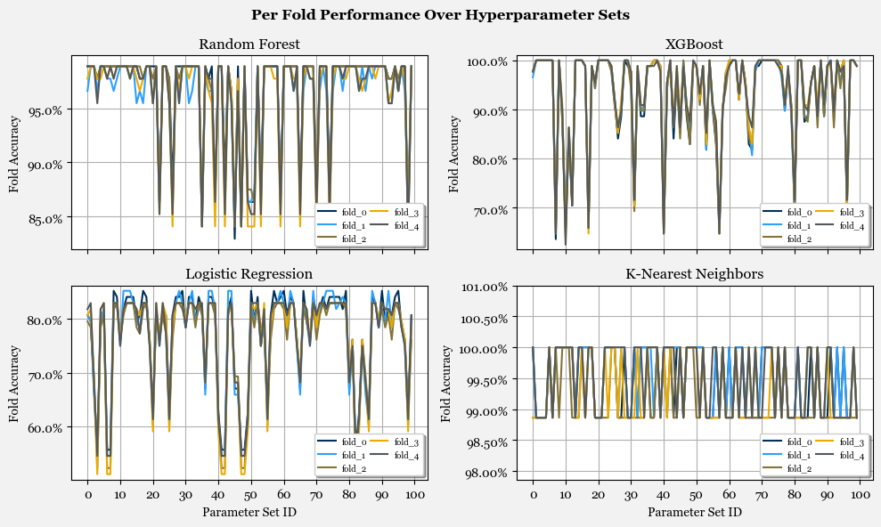

```python
fig, axes = plt.subplots(2, 2, figsize=(10, 6), sharex=True, sharey=False)
axes = axes.flatten()

for i, (k, v) in enumerate(fold_results_melted.items()):
    ax = axes[i]
    sns.lineplot(
        data=v,
        x='param_idx',
        y='score',
        ax=ax,
        hue = 'fold',
        palette = PALETTE_CONTRAST,
        linewidth=1.5,
    ) #style='fold', markers=False,)

    ax.set_title(f'{MODEL_ALIAS[k]}')
    ax.set_ylabel('Fold Accuracy')
    ax.set_xlabel('Parameter Set ID')

    ax.grid(True)
    ax.set_ylim(v.score.min()-0.01, v.score.max()+0.01)
    ax.xaxis.set_major_formatter(mtick.FormatStrFormatter('%.0f'))
    ax.xaxis.set_major_locator(mtick.MultipleLocator(10))
    ax.yaxis.set_major_formatter(mtick.PercentFormatter(1))
    ax.legend(

        loc='lower right',
        fontsize='x-small',
        ncol=2,
        columnspacing=0.3,
        shadow=True,
        )
    #supress legend
    # ax.get_legend().remove()



fig.patch.set_facecolor('#F2F2F2')
fig.suptitle('Per Fold Performance Over Hyperparameter Sets', fontsize='large', fontweight='bold')
plt.tight_layout()
fig.savefig(f'figs/tuned_fold_performance.png', dpi=300, bbox_inches='tight')
plt.show()
```

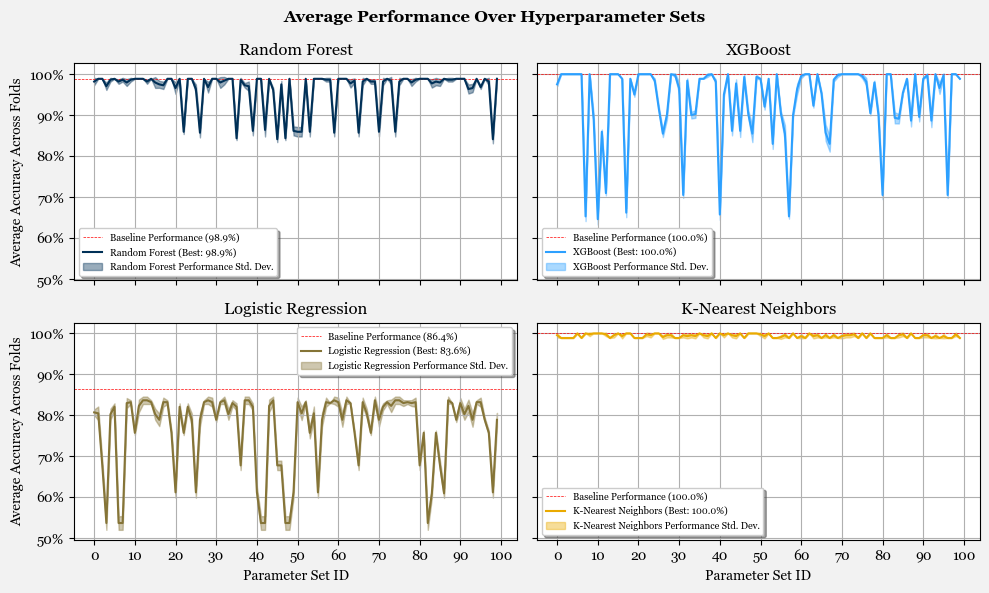

```python
fig, axes = plt.subplots(2, 2, figsize=(10, 6), sharex=True, sharey=True)
axes = axes.flatten()

for i, (k, v) in enumerate(fold_results.items()):
    ax = axes[i]
    ax.axhline(
        y=v.baseline_performance.max(),
        color='red',
        linestyle='--',
        linewidth=0.5,
        label=f'Baseline Performance ({v.baseline_performance.max():.1%})'
        )
    sns.lineplot(
        data=v,
        x='param_idx',
        y='avg_score',
        ax=ax,
        color=PALETTE_QUAD[i],
        label=MODEL_ALIAS[k] +
        f' (Best: {v.avg_score.max():.1%})'
        )
    ax.fill_between(
        v.param_idx,
        v.avg_score - v.std_score,
        v.avg_score + v.std_score,
        alpha=0.4,
        color=PALETTE_QUAD[i],
        label=f'{MODEL_ALIAS[k]} Performance Std. Dev.'
        )

    ax.set_title(f'{MODEL_ALIAS[k]}')
    ax.set_ylabel('Average Accuracy Across Folds')
    ax.set_xlabel('Parameter Set ID')

    ax.grid(True)
    # ax.set_ylim(0.50, 1.01)
    ax.xaxis.set_major_formatter(mtick.FormatStrFormatter('%.0f'))
    ax.xaxis.set_major_locator(mtick.MultipleLocator(10))
    ax.yaxis.set_major_formatter(mtick.PercentFormatter(1))
    ax.legend(
        loc='best',
        fontsize='x-small',
        shadow=True,
        )

fig.patch.set_facecolor('#F2F2F2')
fig.suptitle('Average Performance Over Hyperparameter Sets', fontsize='large', fontweight='bold')
plt.tight_layout()
fig.savefig(f'figs/tuned_performance.png', dpi=300, bbox_inches='tight')
plt.show()
```

# Export Source Code

```python
user = str(pathlib.Path.home()).split('\\')[-1]
export_flag = False
if user != 'bkeith' and user != 'Brian':
    raise Exception('User running code is not the student. No need to run below.')
else:
    export_flag = True
    print('User running code is the student. Continue to file Export.')

cur_file = __vsc_ipynb_file__
output_dir = 'zlogs'
output_name = cur_file.split('\\')[-1].split('.')[0] + f'.html'
cell_tags_exist = False
template = 'classic'

if export_flag == True:
    export_code(
        cur_file,
        output_dir,
        output_name,
        cell_tags_exist,
        template=template,
        conda_path = f'c:/users/{user}/anaconda3/scripts/activate',
        conda_env='PracticumEnv'
    )
```

```
User running code is the student. Continue to file Export.
```